# Data Analysis Assignment #1 (50 points total)

Thakur, Prabhat

The following code chunk will (a) load the ggplot2 and gridExtra packages, assuming each has been installed on your machine, (b) read-in the abalones dataset, defining a new data frame, “mydata,” (c) return the structure of that data frame, and (d) calculate new variables, VOLUME and RATIO. If either package has not been installed, you must do so first via *install.packages()*; e.g. *install.packages(“ggplot2”)*. You will also need to download the abalones.csv from the course site to a known location on your machine.

```
## 'data.frame':    1036 obs. of  8 variables:
##  $ SEX   : Factor w/ 3 levels "F","I","M": 2 2 2 2 2 2 2 2 2 2 ...
##  $ LENGTH: num  5.57 3.67 10.08 4.09 6.93 ...
##  $ DIAM  : num  4.09 2.62 7.35 3.15 4.83 ...
##  $ HEIGHT: num  1.26 0.84 2.205 0.945 1.785 ...
##  $ WHOLE : num  11.5 3.5 79.38 4.69 21.19 ...
##  $ SHUCK : num  4.31 1.19 44 2.25 9.88 ...
##  $ RINGS : int  6 4 6 3 6 6 5 6 5 6 ...
##  $ CLASS : Factor w/ 5 levels "A1","A2","A3",..: 1 1 1 1 1 1 1 1 1 1 ...
```

(1)(a) (1 point) Use *summary()* to obtain and present descriptive statistics from mydata.

```
##  SEX         LENGTH           DIAM            HEIGHT
##  F:326   Min.   : 2.73   Min.   : 1.995   Min.   :0.525
##  I:329   1st Qu.: 9.45   1st Qu.: 7.350   1st Qu.:2.415
##  M:381   Median :11.45   Median : 8.925   Median :2.940
##          Mean   :11.08   Mean   : 8.622   Mean   :2.947
##          3rd Qu.:13.02   3rd Qu.:10.185   3rd Qu.:3.570
##          Max.   :16.80   Max.   :13.230   Max.   :4.935
##      WHOLE             SHUCK              RINGS        CLASS
##  Min.   :  1.625   Min.   :  0.5625   Min.   : 3.000   A1:108
##  1st Qu.: 56.484   1st Qu.: 23.3006   1st Qu.: 8.000   A2:236
##  Median :101.344   Median : 42.5700   Median : 9.000   A3:329
##  Mean   :105.832   Mean   : 45.4396   Mean   : 9.993   A4:188
##  3rd Qu.:150.319   3rd Qu.: 64.2897   3rd Qu.:11.000   A5:175
##  Max.   :315.750   Max.   :157.0800   Max.   :25.000
##      VOLUME            RATIO
##  Min.   :  3.612   Min.   :0.06734
##  1st Qu.:163.545   1st Qu.:0.12241
##  Median :307.363   Median :0.13914
##  Mean   :326.804   Mean   :0.14205
##  3rd Qu.:463.264   3rd Qu.:0.15911
##  Max.   :995.673   Max.   :0.31176
```

**Question (1 point): Briefly discuss the variable types and distributional implications such as potential skewness and outliers.**

(1)(b) (1 point) Generate a table of counts using SEX and CLASS. Add margins to this table (Hint: There should be 15 cells in this table plus the marginal totals. Apply *table()* first, then pass the table object to *addmargins()* (Kabacoff Section 7.2 pages 144-147)). Lastly, present a barplot of these data.

```
##      CLASS
## SEX     A1   A2   A3   A4   A5  Sum
##   F      5   41  121   82   77  326
##   I     91  133   65   21   19  329
##   M     12   62  143   85   79  381
##   Sum  108  236  329  188  175 1036
```

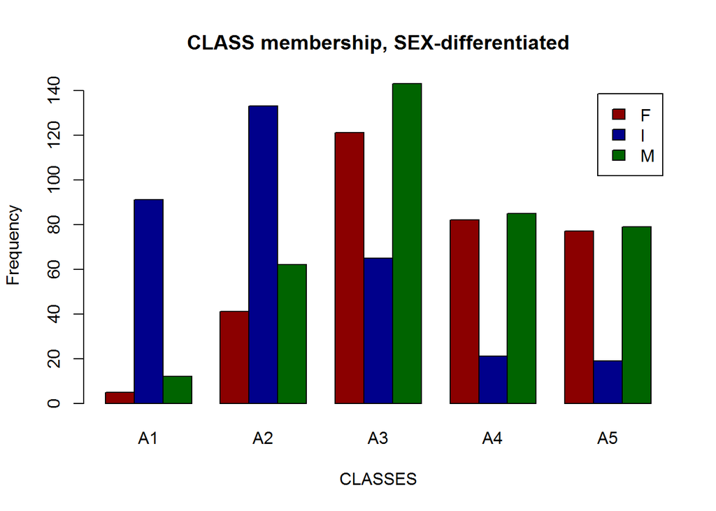

**Question (1 point): Discuss the sex distribution of abalones. What stands out about the distribution of abalones by CLASS?**

*Answer: By analyzing the table of abalone’s SEX and CLASS wise count and related bar plot, we can say that there are about same number of infants, females and males present in the sample dataset and they appears to normally distributed. Infant abalones count is increasing from class A1 to A2 and then decreasing in subsequent classes. Their presence in class A4 and A5 raises questions, class A4 and A5 represents higher number of Rings which should be observed in adult abalones. Female and Male abalones count in class A1 is very less but not a good data for the same reason stated above. Their count in class A3 is highest and after that it decreases. Female and Male count in class A4 and A5 are almost same but overall male count is at little higher side.*

(1)(c) (1 point) Select a simple random sample of 200 observations from “mydata” and identify this sample as “work”. Use *set.seed(123)* prior to drawing this sample. Do not change the number 123. (If you must draw another sample from mydata, it is imperative that you start with *set.seed(123)*, otherwise your second sample will not duplicate your first sample or the “work” sample used for grading your report.) (Kabacoff Section 4.10.5 page 87)

Using this sample, construct a scatterplot matrix of variables 2-6 with *plot(work[, 2:6])* (these are the continuous variables excluding VOLUME and RATIO). The sample “work” will not be used in the remainder of the assignment.

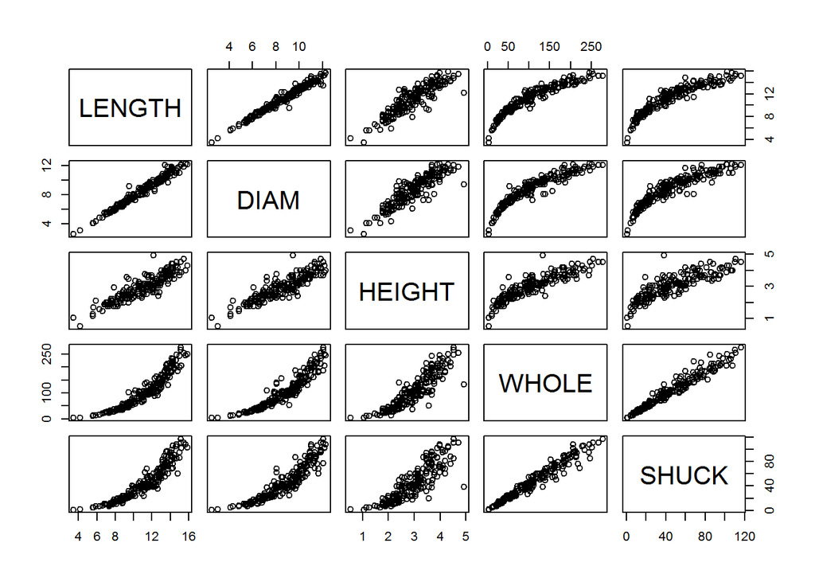

(2)(a) (1 point) Use “mydata” to plot WHOLE versus VOLUME. Color code data points by CLASS.

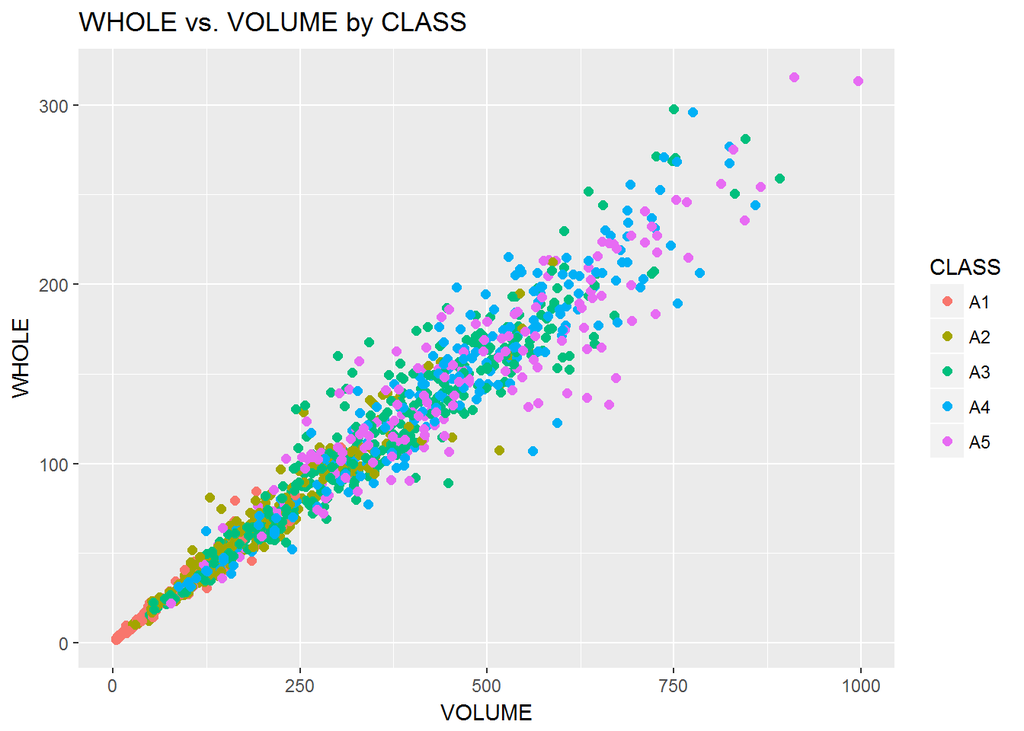

**Question (2 points): What does the wedge-shaped scatter of data points suggest about the relationship between WHOLE and VOLUME? Interpret this plot taking into account abalone physical measurements of length, diameter and heigth and the displays shown in (1)(c).**

*Answer: From plots in (1) (c), it is visible that LENGTH, DIAM, HEIGHT variables are linearly correlated and have positive association. From WHOLE vs VOLUME graph, we can observe that both WHOLE and VOLUME variables have linear and strong relationship, highly correlated and have positive association which means when VOLUME increases WHOLE-weight also increases. Compared to large abalones (high volume), for smaller abalones WHOLE and VOLUME variables are more correlated. As abalones VOLUME grows, WHOLE-weight is less correlated with VOLUME. CLASS A4 and A5 abalones are more scattered and have weak linear relationship and outliers.*

(2)(b) (2 points) Use “mydata” to plot SHUCK versus WHOLE with WHOLE on the horizontal axis. Use a different color for each age class. As an aid to interpretation, determine the maximum value of the ratio of SHUCK to WHOLE. Add to the chart a straight line with zero intercept using this maximum value as the slope of the line. If you are using the ‘base R’ *plot()* function, you may use *abline()* to add this line to the plot. Use *help(abline)* in R to determine the coding for the slope and intercept arguments in the functions. If you are using ggplot2 for visualizations, *geom_abline()* should be used.

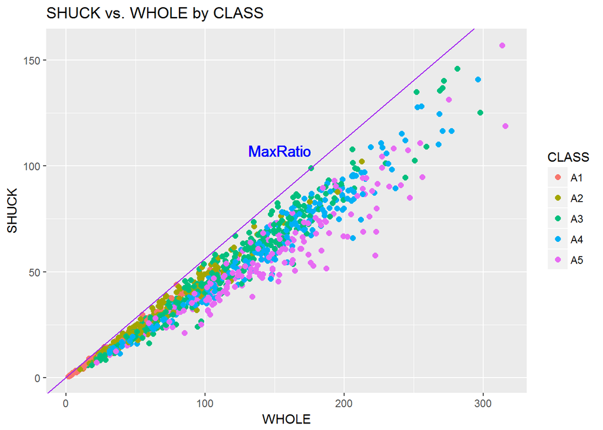

**Question (2 points): How does the variability in this plot differ from the plot in (a)? Compare the two displays. Keep in mind that SHUCK is a part of WHOLE.**

*Answer: From SHUCK to WHOLE plot, we can see that oldest abalones (abalones in CLASS A5) tend to be at bottom of the plot which suggests that for abalones in this CLASS, SHUCK weight doesn’t increase at the same rate as WHOLE weight. For other CLASSes they looks highly correlated. From the purple line which represent the maximum ratio of SHUCK to WHOLE, it shows that as abalones gets older and in CLASS A4 and A5, the SHUCK weight (meat) doesn’t necessarily increases in same proportion as WHOLE-weight. It appears abalones in CLASS A3 and A4 yields most meat with respect to their WHOLE weight as compared to CLASS A5. If we compare the two graphs WHOLE vs VOLUME and SHUCK vs WHOLE, we can say that, VOLUME and WHOLE are more correlated compared to SHUCK and WHOLE. SHUCK-weight data doesn’t seems to be as useful as VOLUME variable in this study.*

(3)(a) (2 points) Use “mydata” to create a multi-figured plot with histograms, boxplots and Q-Q plots of RATIO differentiated by sex. This can be done using *par(mfrow = c(3,3))* and base R or *grid.arrange()* and ggplot2. The first row would show the histograms, the second row the boxplots and the third row the Q-Q plots. Be sure these displays are legible.

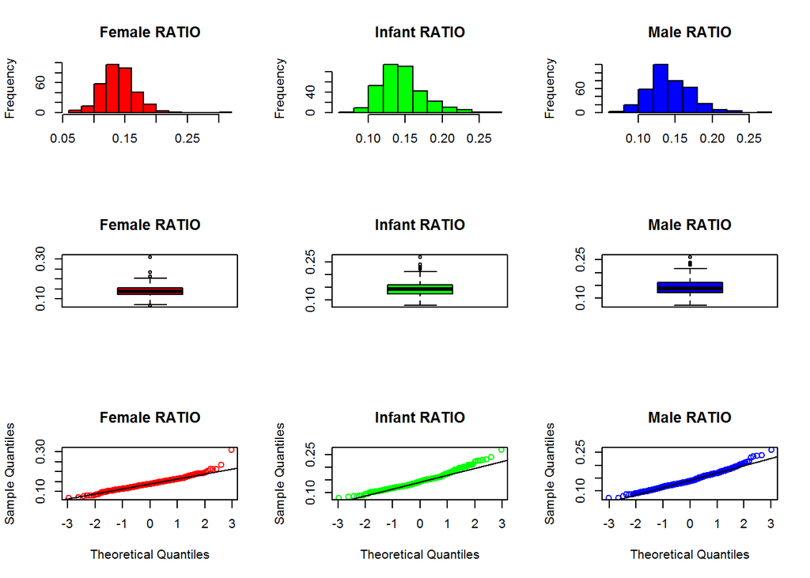

**Question (2 points): Compare the displays. How do the distributions compare to normality? Take into account the criteria discussed in the sync sessions.**

*Answer: The relationship between RATIO (ratio of SHUCK to VOLUME) and SEX is displayed in the above graphs. In the first row, histograms of RATIO differentiated by SEX is displayed. All three histograms appears to be non-normal and right skewed and this can be proved from the respective boxplots in the 2nd row. 2nd row shows that there are outliers present in all three boxplots. Using boxplot.stats() and coef =3, we can find that female and infant each has 1 extreme outliners as well. Analyzing skewness and kurtosis values of these distribution confirms that all three distributions are non-normal distribution and are right skewed as there skewness is > 0. For all three, Kurtosis value is > 3 which suggests that they are heavy-tailed. Male distribution is closest to the normal distribution compared to other two. Their reason for departure from normal distribution can be linked to the presence of more outliers in Female and Infant compared to Male. Looking at Q-Q Plot in the 3rd row, we can see that in the upper right corner data points are departing from the normal distribution line, this also suggests that data is right skewed. We can see this behavior more in female and infant data set. Analyzing all three types of graphs confirms that RATIO data is right skewed in all three SEX categories, it has outliers and their distribution are non-normal however very close to normal distribution.*

(3)(b) (2 points) Use the boxplots to identify RATIO outliers. Present the abalones with these outlying RATIO values along with their associated variables in “mydata.” Hint: Construct a listing of the observations using the kable() function.

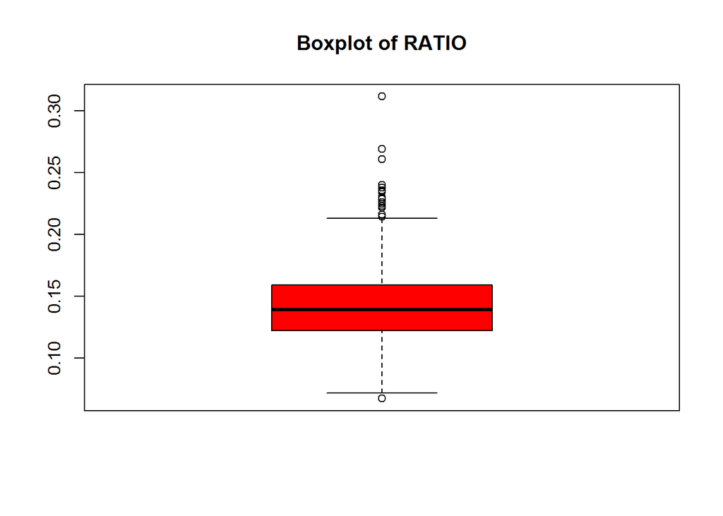

```
## List of outliers in RATIO data, sorted for easy read
```

```
##  [1] 0.06733877 0.21465603 0.21627955 0.22183084 0.22323389 0.22495771
##  [7] 0.22632940 0.22867353 0.22904785 0.23007038 0.23459236 0.23497668
## [13] 0.23563492 0.23787636 0.24033943 0.26098609 0.26933712 0.31176204
```

|  | SEX | LENGTH | DIAM | HEIGHT | WHOLE | SHUCK | RINGS | CLASS | VOLUME | RATIO |
| --- | --- | --- | --- | --- | --- | --- | --- | --- | --- | --- |
| 3 | I | 10.080 | 7.350 | 2.205 | 79.37500 | 44.00000 | 6 | A1 | 163.364040 | 0.2693371 |
| 37 | I | 4.305 | 3.255 | 0.945 | 6.18750 | 2.93750 | 3 | A1 | 13.242072 | 0.2218308 |
| 42 | I | 2.835 | 2.730 | 0.840 | 3.62500 | 1.56250 | 4 | A1 | 6.501222 | 0.2403394 |
| 58 | I | 6.720 | 4.305 | 1.680 | 22.62500 | 11.00000 | 5 | A1 | 48.601728 | 0.2263294 |
| 67 | I | 5.040 | 3.675 | 0.945 | 9.65625 | 3.93750 | 5 | A1 | 17.503290 | 0.2249577 |
| 89 | I | 3.360 | 2.310 | 0.525 | 2.43750 | 0.93750 | 4 | A1 | 4.074840 | 0.2300704 |
| 105 | I | 6.930 | 4.725 | 1.575 | 23.37500 | 11.81250 | 7 | A2 | 51.572194 | 0.2290478 |
| 200 | I | 9.135 | 6.300 | 2.520 | 74.56250 | 32.37500 | 8 | A2 | 145.027260 | 0.2232339 |
| 350 | F | 7.980 | 6.720 | 2.415 | 80.93750 | 40.37500 | 7 | A2 | 129.505824 | 0.3117620 |
| 420 | F | 11.550 | 7.980 | 3.465 | 150.62500 | 68.55375 | 10 | A3 | 319.365585 | 0.2146560 |
| 458 | F | 11.445 | 8.085 | 3.150 | 139.81250 | 68.49062 | 9 | A3 | 291.478399 | 0.2349767 |
| 586 | F | 12.180 | 9.450 | 4.935 | 133.87500 | 38.25000 | 14 | A5 | 568.023435 | 0.0673388 |
| 746 | M | 13.440 | 10.815 | 1.680 | 130.25000 | 63.73125 | 10 | A3 | 244.194048 | 0.2609861 |
| 754 | M | 10.500 | 7.770 | 3.150 | 132.68750 | 61.13250 | 9 | A3 | 256.992750 | 0.2378764 |
| 803 | M | 10.710 | 8.610 | 3.255 | 160.31250 | 70.41375 | 9 | A3 | 300.153640 | 0.2345924 |
| 810 | M | 12.285 | 9.870 | 3.465 | 176.12500 | 99.00000 | 10 | A3 | 420.141472 | 0.2356349 |
| 852 | M | 11.550 | 8.820 | 3.360 | 167.56250 | 78.27187 | 10 | A3 | 342.286560 | 0.2286735 |
| 870 | M | 11.445 | 8.610 | 2.520 | 99.12500 | 53.70750 | 9 | A3 | 248.324454 | 0.2162795 |

**Question (2 points): What are your observations regarding the results in (3)(b)?**

*Answer: Mean of RATIO variable is: 0.14205. In RATIO outliers data, there are 8 outliers in infant category out of which 1 (row 1) has extraordinary VOLUME and WHOLE-weight with respect to its RINGS count and CLASS. All other data for that infant appears to be good and looks like the RINGS measurement could be wrongly recorded. There are 4 outliers in female category out of which 1 (row 12) has very less SHUCK weight compared to its VOLUME and other physical measurements. Looks like recorded SHUCK for this abalone is not correct. There are 6 outliers in male category and all are from CLASS A3, which suggests that male abalones in CLASS A3 gives most meat with respect to their VOLUME. For one of the male outlier (row 13) HEIGHT is less compared to other measurements due to which its calculated VOLUME is less hence making this data an outliner, this recording appears to be wrong. As abalones volume increases (size) the SHUCK weight doesn’t increase in the same ratio. More study is required to see if SHUCK weight is important variable to study abalones age or not.*

(4)(a) (3 points) With “mydata,” display two separate sets of side-by-side boxplots for VOLUME and WHOLE differentiated by CLASS (Davies Section 14.3.2). Show five boxplots for VOLUME in one display and five boxplots for WHOLE (making two separate displays). Also, create two separate scatterplots of VOLUME and WHOLE versus RINGS. Present these displays in one graphic, the boxplots in one row and the scatterplots in a second row. Base R or ggplot2 may be used.

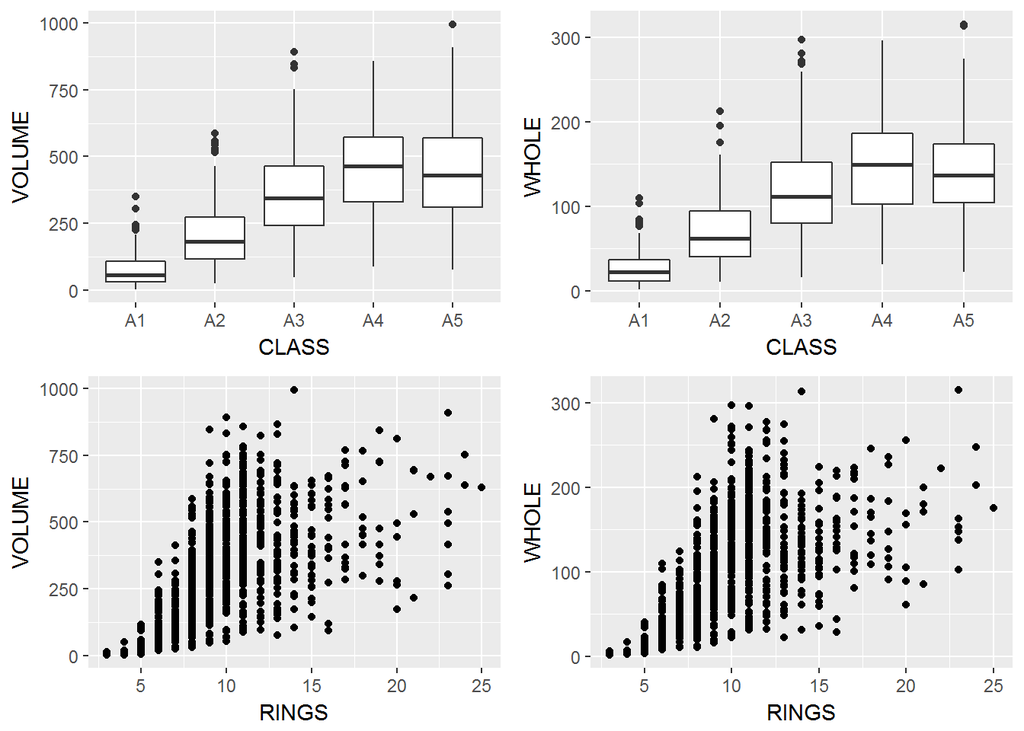

**Question (5 points) How well do you think these variables would perform as predictors of age?**

*Answer: In above boxplots of VOLUME and WHOLE differentiated by CLASS, we can see clear distinction of VOLUME change at each CLASS from CLASS A1 to A3 and it is highly correlated. It seems to be possible to categories abalones in CLASSes based on VOLUME and WHOLE for smaller abalones. Unfortunately for CLASS A4 and A5 this is not true. Other predictors like LENGTH, DIAM and HIGHT should be used along with Volume and Whole to classify CLASS A4 and A5, further analysis is required on this. From analyzing scatterplots of VOLUME and WHOLE vs. RINGS, we can say that most of the abalones falls between 5 to 20 RINGS. Unfortunately both VOLUME and WHOLE pretty much distributes across all RINGS count. There is no strong relationship between RINGSs verses VOLUME and WHOLE. It appears, RINGS count variable in the abalone data is not a good predictor of abalones age and one of the reason could be difficulty in measuring it which could produce wrong measurements. To summarize, VOLUME and WHOLE seems to be good predictors for abalones in CLASS A1 to A3. For abalones in CLASS A4 and A5, other measurements are also required as predictors of age. Further analysis is required on this. RINGS count doesn’t seems to be very useful predictor of age compared to VOLUME and WHOLE.*

(5)(a) (2 points) Use *aggregate()* with “mydata” to compute the mean values of VOLUME, SHUCK and RATIO for each combination of SEX and CLASS. Then, using *matrix()*, create matrices of the mean values. Using the “dimnames” argument within *matrix()* or the *rownames()* and *colnames()* functions on the matrices, label the rows by SEX and columns by CLASS. Present the three matrices (Kabacoff Section 5.6.2, p. 110-111). You do not need to be concerned with the number of digits presented.

```
## Volume Average by Sex and Class:
```

```
##               A1       A2       A3       A4       A5
## Female 255.29938 276.8573 412.6079 498.0489 486.1525
## Infant  66.51618 160.3200 270.7406 316.4129 318.6930
## Male   103.72320 245.3857 358.1181 442.6155 440.2074
```

```
##
## Shuck Average by Sex and Class:
```

```
##              A1       A2       A3       A4       A5
## Female 38.90000 42.50305 59.69121 69.05161 59.17076
## Infant 10.11332 23.41024 37.17969 39.85369 36.47047
## Male   16.39583 38.33855 52.96933 61.42726 55.02762
```

```
##
## Ratio Average by Sex and Class:
```

```
##               A1        A2        A3        A4        A5
## Female 0.1546644 0.1554605 0.1450304 0.1379609 0.1233605
## Infant 0.1569554 0.1475600 0.1372256 0.1244413 0.1167649
## Male   0.1512698 0.1564017 0.1462123 0.1364881 0.1262089
```

(5)(b) (3 points) Present three graphs. Each graph should be generated with three separate lines appearing, one for each sex. The first should show mean RATIO versus CLASS; the second, average VOLUME versus CLASS; the third, SHUCK versus CLASS. This may be done with the ‘base R’ *interaction.plot()* function or with ggplot2.

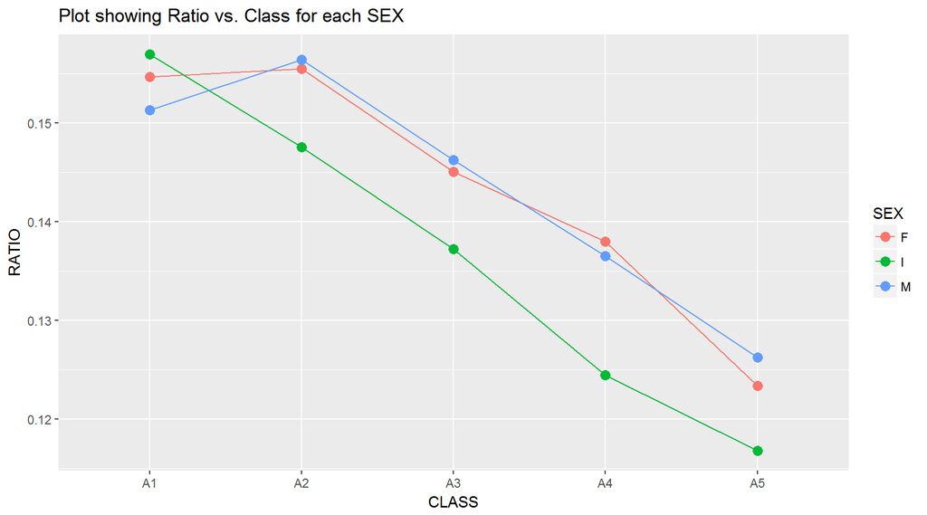

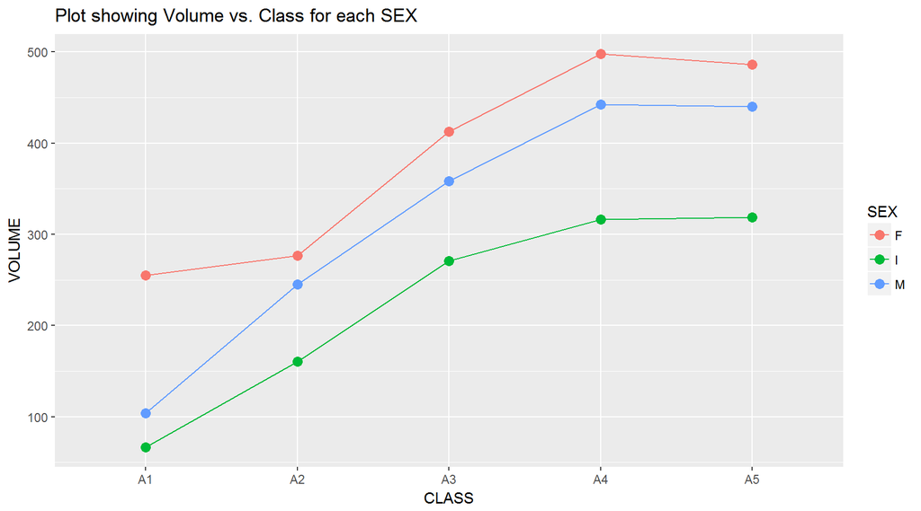

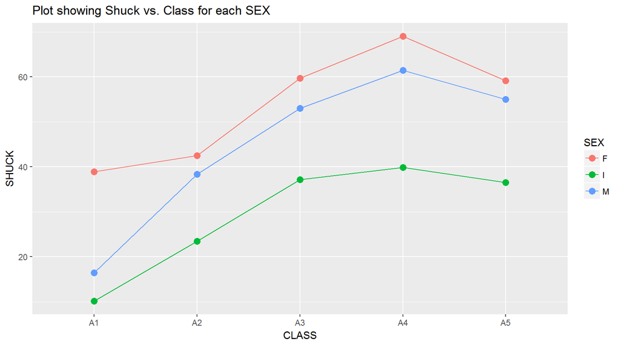

**Question (2 points): What questions do these plots raise? Discuss.**

*Answer: In the first plot RATIO vs CLASS, in all three SEX categories, as abalones gets older their average RATIO is dropping except for male and female from CLASS A1 to A2, that means SHUCK is not increasing in the same ratio as VOLUME. In other two plots, VOLUME vs. CLASS and SHUCK vs. CLSSS, VOLUME and SHUCK growth is consistent with abalones age. However average VOLUME doesn’t change from CLASS A4 to A5 and average SHUCK weight is dropping from CLASS A4 to A5. One more point to note is, female average VOLUME and SHUCK is quite height compared to other SEX in CLASS A1. This raises question if female in CLASS A1 are correctly classified. More investigation is required on this.*

5(c) (3 points) Present four different boxplot displays using *par(mfrow = c(2, 2)*. The first line would show VOLUME by RINGS for the infants and the adults (factor levels “M” and “F” combined), The second line would show WHOLE by RINGS for the infants and the adults (factor levels “M” and “F” combined). Since the data are sparse beyond 15 rings, limit the displays to less than 16 rings. Use ylim = c(0,1100) for VOLUME and ylim = c(0, 400) for WHOLE. If you wish to reorder the displays for presentation purposes or use ggplot2 go ahead.

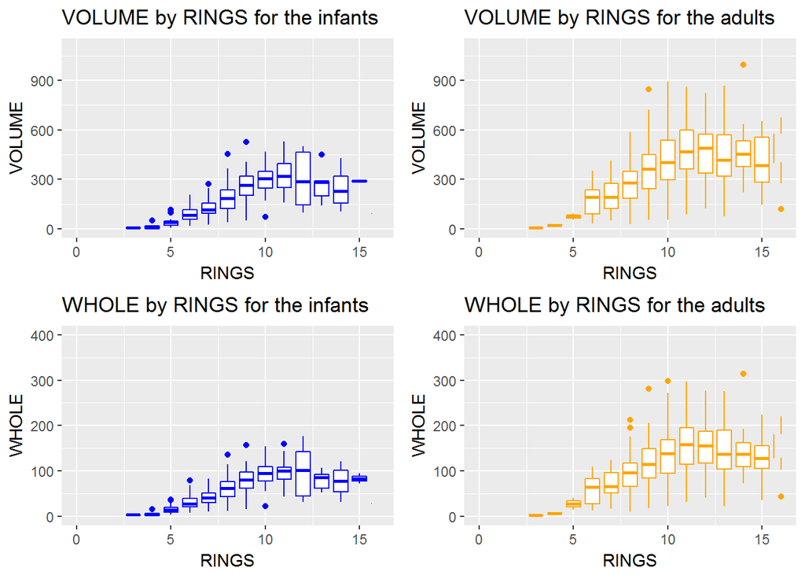

**Question (2 points): Abalone growth is said to decline when they have more than ten rings. Do you see trends in these plots to support this statement?**

*Answer: To validate this statement, I created boxplot for each RINGS count to examine the growth trend. Both VOLUME and WHOLE growth in Infants and Adults are similar. The statement “Abalone growth is said to decline when they have more than ten rings” is not entirely true. In Infants, we can see growth until RINGS count is 11 and after that it declines a little bit but pretty much remains study. Same pattern we can see in Adults where we can see growth until RINGS count is 12 and after that it declines a little bit but again pretty much remains study. Hence the statement is not completely true.*

**Conclusions**

Please respond to each of the following questions (8 points total):

**Question 1) (5 points) What are plausible reasons that explain the failure of the original study? Consider to what extent abalone physical measurements may be used for predicting age.**

*Answer: After studying the data we found that there are outliers in pretty much all the physical measurements. Further investigation is required to confirm if those outliers are genuine or should be dropped from the study. Length, Height and Diameter are relatively linear correlated. We can assume that bigger the abalone, the heavier they are but from the analysis we found that Volume and Whole-weight is highly correlated for small abalone only. So this correlation cannot be used for older abalones. All three SEX data has been distributed across all 5 Classes which makes the study difficult. Certainly Length, Height, Diameter, Volume and Whole-weight are important measurements for the study however more detailed analysis of physical measurements and additional information to justify the outliers are required to build a better model to predict abalones age.*

**Question 2) (3 points) Setting the abalone data and analysis aside, if you were presented with an overall histogram and summary statistics from a sample and no other information, what questions might you ask before accepting them as representative of the sampled population?**

*Answer: There are several question that should be asked before accepting any sample as representative of the sampled population like: 1. What is the objective of study? 2. How old is the data sample? Any major changes in the population frame at the time of study. 3. How sample was collected. What sampling/survey technique were used? 4. Is the sample size good enough for the particular study? 5. Was there any bias in the sample selection methodology? 6. Is the data collected enough to conduct the study. 7. Can the inference from sample be applied on the population?*

**Question 3) (2 points) What do you see as difficulties when drawing conclusions from observational studies? Can causality be determined? What might be learned from such studies?**

*Answer: In general, association does not imply causation, due to the fact that lurking variables might be responsible for the association we observe, which means we cannot establish that there is a causal relationship between our “explanatory” variable and our response variable. We saw that in observational studies, the best we can do is to control for what we think might be potential lurking variables, but we can never be sure that there aren’t any others that we didn’t anticipate. Therefore, we can come closer to establishing causation, but never really establish it. The only way we can, at least in theory, eliminate the effect of (or control for) ALL lurking variables is by conducting a randomized controlled experiment, in which subjects are randomly assigned to one of the treatment groups. Only in this case can we interpret an observed association as causation.*